# Deep Dive on EOD Changes with Testasterone Treatment (Averaged Data, No Normalization)

## Ratio of vP2 to vP1

A larger negative value means that P2 is “bigger” than P1. We can see that VP2 is always larger on the first day, but becomes more proportional after 8 days of T treatment. Does this suggest less Na+ expression?

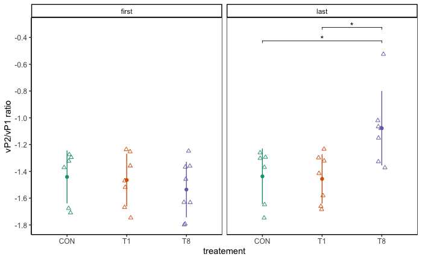

```r
plot <- create_significance_plot(
  data = filt_eod_measurement_data,
  y_variable = "vP2.vP1.ratio",
  y_axis_label = "vP2/vP1 ratio"
)

# Display the plot
print(plot)
```

```r
plot <- create_significance_plot(
  data = filt_eod_measurement_data,
  y_variable = "vP2",
  y_axis_label = "vP2"
)
```

```
No significant differences found between groups.
```

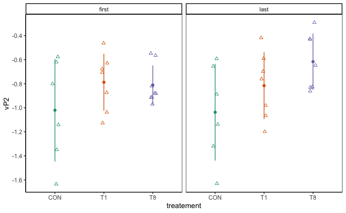

```r
# Display the plot
print(plot)
```

```r
plot <- create_significance_plot(
  data = filt_eod_measurement_data,
  y_variable = "vP1",
  y_axis_label = "vP1"
)
```

```
No significant differences found between groups.
```

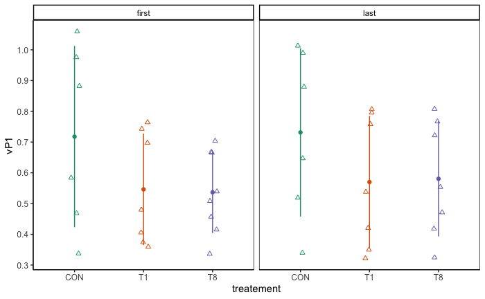

```r
# Display the plot
print(plot)
```

## P1-P2 Delay

Since P1 is defined as T=0, then tP2 is the relative timing of P2. We can see that it takes longer to reach P2 after 8 days of T treatment, suggesting the action potentials are delayed relative to each other (capacitance?)

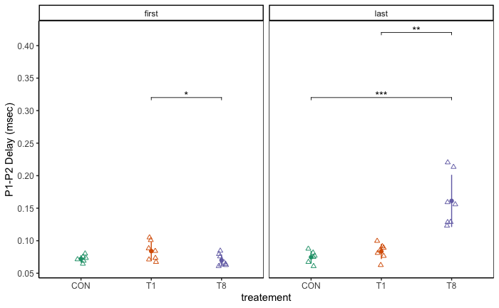

```r
plot <- create_significance_plot(
  data = filt_eod_measurement_data,
  y_variable = "tP2",
  y_axis_label = "P1-P2 Delay (msec)"
)

# Display the plot
print(plot)
```

## P2 Decay Time Constant

The decay constant τ inversely correlates with the rate at which the signal decreases, therefore A smaller τ indicates that the decay happens more rapidly. This means P2’s amplitude diminishes in a shorter time after testasterone treatment. This suggests increased potassium channel expression, I think.

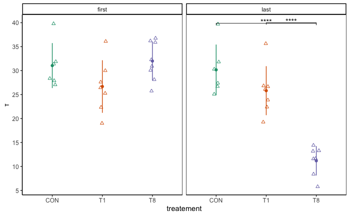

```r
plot <- create_significance_plot(
  data = filt_eod_measurement_data,
  y_variable = "decay_tau",
  y_axis_label = "τ"
)

# Display the plot
print(plot)
```

## Slope of P1

There is no significant difference here.

```r
plot <- create_significance_plot(
  data = filt_eod_measurement_data,
  y_variable = "sS1",
  y_axis_label = "Slope of P1"
)
```

```
No significant differences found between groups.
```

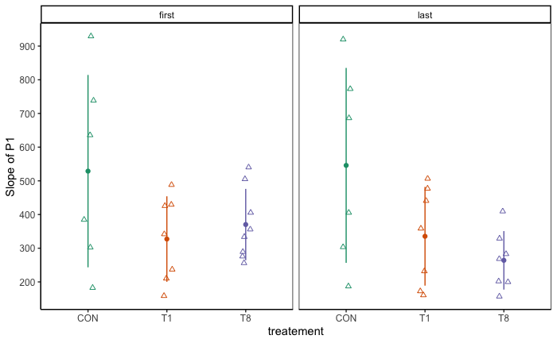

```r
# Display the plot
print(plot)
```

## P0

```r
plot <- create_significance_plot(
  data = filt_eod_measurement_data,
  y_variable = "aP0",
  y_axis_label = "Area P0"
)
```

```
No significant differences found between groups.
```

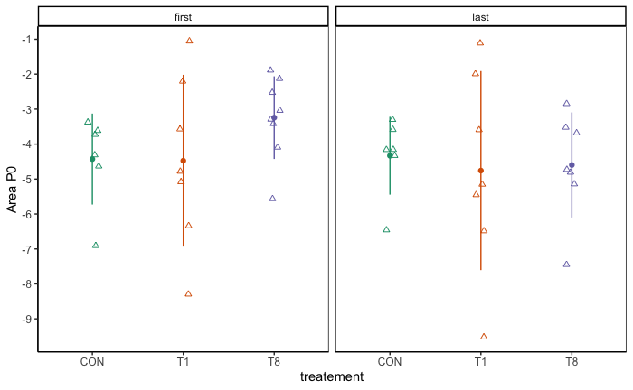

```r
# Display the plot
print(plot)
```

```r
plot <- create_significance_plot(
  data = filt_eod_measurement_data,
  y_variable = "vP0",
  y_axis_label = "Voltage of P0"
)
```

```
No significant differences found between groups.
```

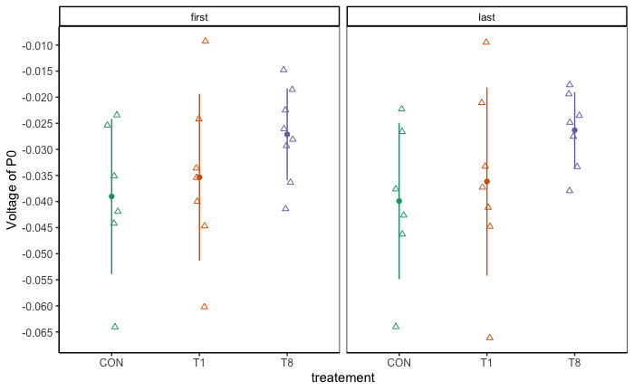

```r
# Display the plot
print(plot)
```

## Summary Table of All Comparisions

This code generates a summary table and outputs to word for editing and inclusion in the manuscript.

```r
statistics <- c("duration", "p1_duration", "p2_duration", "vP2.vP1.ratio", "tP2", "decay_tau","aP0","vP0","sS1","vP1","vP2")

# Filter, summarize, and format
summary_table <- filt_eod_measurement_data %>%
  group_by(treat_day, treatement) %>%            # Group by n_days and treatment
  summarise(across(all_of(statistics),
                   ~ sprintf("%.2f ± %.2f",
                             mean(.x, na.rm = TRUE),
                             sd(.x, na.rm = TRUE)),
                   .names = "{col}")) %>%     # Combine mean and sd into a single column
  ungroup()                                   # Remove grouping
colnames(summary_table)<-c("Treatment Day","Treatment","Duration","P1 Duration","P2 Duration","vP2/vP1","tP2","τ","aP0","vP0","sS1","vP1","vP2")

# Create the flextable
flextable_table <- flextable(summary_table) %>%
  bg(part = "header", bg = "#D3D3D3") %>%  # Set header background color
  bold(part = "header") %>%               # Bold the header row
  fontsize(size = 10, part = "all") %>%   # Set font size for the entire table
  autofit() %>%                           # Adjust column widths
  set_table_properties(layout = "autofit") %>%      # Fit table to layout
  line_spacing(i = NULL, space = 1.2)     # Add line spacing for better readability

# Define landscape section properties
landscape_section <- block_section(
  prop_section(
    page_size = page_size(orient = "landscape") # Set the page orientation to landscape
  )
)

# Create the Word document
doc <- read_docx() %>%
  body_add_flextable(flextable_table) %>% # Add the flextable
  body_add(landscape_section)      # Apply landscape section properties


# Export the Word document
print(doc, target = file.path(root,"output_data/eod_summary_avg.docx"))

flextable_table
```

| Treatment Day | Treatment | Duration | P1 Duration | P2 Duration | vP2/vP1 | tP2 | τ | aP0 | vP0 | sS1 | vP1 | vP2 |
| --- | --- | --- | --- | --- | --- | --- | --- | --- | --- | --- | --- | --- |
| first | CON | 0.68 ± 0.13 | 0.03 ± 0.00 | 0.04 ± 0.00 | -1.44 ± 0.20 | 0.07 ± 0.01 | 31.05 ± 4.69 | -4.43 ± 1.30 | -0.04 ± 0.01 | 528.82 ± 285.50 | 0.72 ± 0.29 | -1.02 ± 0.43 |
| first | T1 | 0.78 ± 0.07 | 0.04 ± 0.00 | 0.04 ± 0.01 | -1.46 ± 0.20 | 0.08 ± 0.01 | 26.68 ± 5.49 | -4.48 ± 2.46 | -0.04 ± 0.02 | 327.25 ± 126.85 | 0.55 ± 0.18 | -0.79 ± 0.24 |
| first | T8 | 0.69 ± 0.09 | 0.03 ± 0.00 | 0.04 ± 0.00 | -1.54 ± 0.21 | 0.07 ± 0.01 | 32.00 ± 4.05 | -3.24 ± 1.18 | -0.03 ± 0.01 | 370.26 ± 105.85 | 0.54 ± 0.13 | -0.81 ± 0.16 |
| last | CON | 0.68 ± 0.14 | 0.04 ± 0.01 | 0.04 ± 0.00 | -1.44 ± 0.21 | 0.07 ± 0.01 | 30.17 ± 5.28 | -4.33 ± 1.11 | -0.04 ± 0.01 | 545.86 ± 289.28 | 0.73 ± 0.27 | -1.04 ± 0.40 |
| last | T1 | 0.83 ± 0.09 | 0.04 ± 0.01 | 0.04 ± 0.01 | -1.46 ± 0.18 | 0.08 ± 0.01 | 25.82 ± 5.11 | -4.76 ± 2.85 | -0.04 ± 0.02 | 335.43 ± 146.47 | 0.57 ± 0.21 | -0.82 ± 0.28 |
| last | T8 | 1.35 ± 0.20 | 0.07 ± 0.01 | 0.09 ± 0.03 | -1.08 ± 0.28 | 0.16 ± 0.04 | 11.18 ± 3.07 | -4.60 ± 1.50 | -0.03 ± 0.01 | 264.03 ± 86.82 | 0.58 ± 0.19 | -0.62 ± 0.23 |